# https://github.com/Nille30/Peer-Graded-Assignment-Prediction-Assignment-Writeup

Nille30

4/14/2020

# Background

Using devices such as Jawbone Up, Nike FuelBand, and Fitbit it is now possible to collect a large amount of data about personal activity relatively inexpensively. These type of devices are part of the quantified self movement - a group of enthusiasts who take measurements about themselves regularly to improve their health, to find patterns in their behavior, or because they are tech geeks. One thing that people regularly do is quantify how much of a particular activity they do, but they rarely quantify how well they do it. In this project, your goal will be to use data from accelerometers on the belt, forearm, arm, and dumbell of 6 participants. They were asked to perform barbell lifts correctly and incorrectly in 5 different ways. More information is available from the website here: http://web.archive.org/web/20161224072740/http:/groupware.les.inf.puc-rio.br/har (see the section on the Weight Lifting Exercise Dataset).

# Objective

The goal of your project is to predict the manner in which they did the exercise. This is the “classe” variable in the train set. This report describes how data was cleaned, how “pml-training.csv” was split into train set and test set, the models investigated.

# Data Loading, preparation and processing

```r
library(readr)
setwd("/Users/nilsgimpl/Desktop/Coding/R_data/datasciencecoursera/Data_Science_Statistical_Interfence/Peer-Graded-Assignment-Prediction-Assignment-Writeup")
urlTrain <- "https://d396qusza40orc.cloudfront.net/predmachlearn/pml-training.csv"
urlTest <- "https://d396qusza40orc.cloudfront.net/predmachlearn/pml-testing.csv"
download.file(urlTrain,destfile="training_data.csv")
download.file(urlTest,destfile="testing_data.csv")
train <- read.csv("training_data.csv",na.strings = c("NA", "#DIV/0!", ""))
test <- read.csv("testing_data.csv",na.strings = c("NA", "#DIV/0!", ""))
```

## Removing irrelevant variables and columns with NA values

```r
train <- train[, which(colSums(is.na(train)) == 0)]
test <- test[, which(colSums(is.na(test)) == 0)]
train <- train[,-c(1:7)]
test <- test[,-c(1:7)]
```

## Partioning the training set into training and crossvalidation datasets

```r
library(caret)
set.seed(123)
train = data.frame(train)
fitData <- createDataPartition(train$classe, p=0.70, list=F)
train <- train[fitData, ]
val <- train[-fitData, ]
```

# Building a model and cross validation

## Regression Tree Model (rpart)

```r
model1 <- train(classe ~ ., method="rpart", data=train)
val1 <- predict(model1, val)
confusionMatrix(val$classe, val1)
```

```
## Confusion Matrix and Statistics
##
##           Reference
## Prediction    A    B    C    D    E
##          A 1073   15   82    0    5
##          B  382  239  174    0    0
##          C  347   25  344    0    0
##          D  277  127  271    0    0
##          E  114   98  196    0  349
##
## Overall Statistics
##
##                Accuracy : 0.4869
##                  95% CI : (0.4715, 0.5023)
##     No Information Rate : 0.5325
##     P-Value [Acc > NIR] : 1
##
##                   Kappa : 0.328
##
##  Mcnemar's Test P-Value : NA
##
## Statistics by Class:
##
##                      Class: A Class: B Class: C Class: D Class: E
## Sensitivity            0.4893  0.47421  0.32240       NA  0.98588
## Specificity            0.9470  0.84615  0.87807   0.8361  0.89160
## Pos Pred Value         0.9132  0.30063  0.48045       NA  0.46103
## Neg Pred Value         0.6194  0.92025  0.78748       NA  0.99851
## Prevalence             0.5325  0.12239  0.25911   0.0000  0.08596
## Detection Rate         0.2606  0.05804  0.08354   0.0000  0.08475
## Detection Prevalence   0.2853  0.19305  0.17387   0.1639  0.18383
## Balanced Accuracy      0.7181  0.66018  0.60024       NA  0.93874
```

## Random Forest Model (rf)

```r
model2 <- train(classe ~ ., method="rf", data=train, prox=TRUE,ntree=50)
val2 <- predict(model2, val)
confusionMatrix(val$classe, val2)
```

```
## Confusion Matrix and Statistics
##
##           Reference
## Prediction    A    B    C    D    E
##          A 1175    0    0    0    0
##          B    0  795    0    0    0
##          C    0    0  716    0    0
##          D    0    0    0  675    0
##          E    0    0    0    0  757
##
## Overall Statistics
##
##                Accuracy : 1
##                  95% CI : (0.9991, 1)
##     No Information Rate : 0.2853
##     P-Value [Acc > NIR] : < 2.2e-16
##
##                   Kappa : 1
##
##  Mcnemar's Test P-Value : NA
##
## Statistics by Class:
##
##                      Class: A Class: B Class: C Class: D Class: E
## Sensitivity            1.0000   1.0000   1.0000   1.0000   1.0000
## Specificity            1.0000   1.0000   1.0000   1.0000   1.0000
## Pos Pred Value         1.0000   1.0000   1.0000   1.0000   1.0000
## Neg Pred Value         1.0000   1.0000   1.0000   1.0000   1.0000
## Prevalence             0.2853   0.1931   0.1739   0.1639   0.1838
## Detection Rate         0.2853   0.1931   0.1739   0.1639   0.1838
## Detection Prevalence   0.2853   0.1931   0.1739   0.1639   0.1838
## Balanced Accuracy      1.0000   1.0000   1.0000   1.0000   1.0000
```

## Boosted Trees Model (gbm)

```r
model3 <- train(classe ~ ., method="gbm", data=train,trControl=trainControl(method = "repeatedcv", number = 5, repeats = 1),verbose=FALSE)
val3 <- predict(model3, val)
confusionMatrix(val$classe, val3)
```

```
## Confusion Matrix and Statistics
##
##           Reference
## Prediction    A    B    C    D    E
##          A 1160   10    2    2    1
##          B   17  768   10    0    0
##          C    0   12  694    9    1
##          D    0    2   18  651    4
##          E    0    0    2    2  753
##
## Overall Statistics
##
##                Accuracy : 0.9777
##                  95% CI : (0.9727, 0.982)
##     No Information Rate : 0.2858
##     P-Value [Acc > NIR] : < 2.2e-16
##
##                   Kappa : 0.9717
##
##  Mcnemar's Test P-Value : NA
##
## Statistics by Class:
##
##                      Class: A Class: B Class: C Class: D Class: E
## Sensitivity            0.9856   0.9697   0.9559   0.9804   0.9921
## Specificity            0.9949   0.9919   0.9935   0.9931   0.9988
## Pos Pred Value         0.9872   0.9660   0.9693   0.9644   0.9947
## Neg Pred Value         0.9942   0.9928   0.9906   0.9962   0.9982
## Prevalence             0.2858   0.1923   0.1763   0.1612   0.1843
## Detection Rate         0.2817   0.1865   0.1685   0.1581   0.1829
## Detection Prevalence   0.2853   0.1931   0.1739   0.1639   0.1838
## Balanced Accuracy      0.9902   0.9808   0.9747   0.9867   0.9955
```

The comparison shows that the random forest model has the highest accuarcy of the three model. Therefore, it will be used for the prediction of the test samples.

## Linear Discriminant Analysis Model

```r
model4 <- train(classe ~ ., data = train, method = "lda")
val4 <- predict(model4, newdata = val)
confusionMatrix(val$classe, val4)
```

```
## Confusion Matrix and Statistics
##
##           Reference
## Prediction   A   B   C   D   E
##          A 958  34  96  84   3
##          B 132 488  90  40  45
##          C  73  72 461  95  15
##          D  32  25  77 512  29
##          E  24 134  66  73 460
##
## Overall Statistics
##
##                Accuracy : 0.6991
##                  95% CI : (0.6849, 0.7131)
##     No Information Rate : 0.296
##     P-Value [Acc > NIR] : < 2.2e-16
##
##                   Kappa : 0.6193
##
##  Mcnemar's Test P-Value : < 2.2e-16
##
## Statistics by Class:
##
##                      Class: A Class: B Class: C Class: D Class: E
## Sensitivity            0.7859   0.6481   0.5835   0.6368   0.8333
## Specificity            0.9251   0.9088   0.9234   0.9508   0.9167
## Pos Pred Value         0.8153   0.6138   0.6439   0.7585   0.6077
## Neg Pred Value         0.9113   0.9203   0.9033   0.9152   0.9726
## Prevalence             0.2960   0.1829   0.1918   0.1952   0.1340
## Detection Rate         0.2326   0.1185   0.1119   0.1243   0.1117
## Detection Prevalence   0.2853   0.1931   0.1739   0.1639   0.1838
## Balanced Accuracy      0.8555   0.7784   0.7535   0.7938   0.8750
```

# Prediction

Random forest model is used for the prediction

```r
pred <- predict(model2, newdata=test)
pred
```

```
##  [1] B A B A A E D B A A B C B A E E A B B B
## Levels: A B C D E
```

# Appendix

## Plot of the decision tree (rpart)

```r
library(rattle)
```

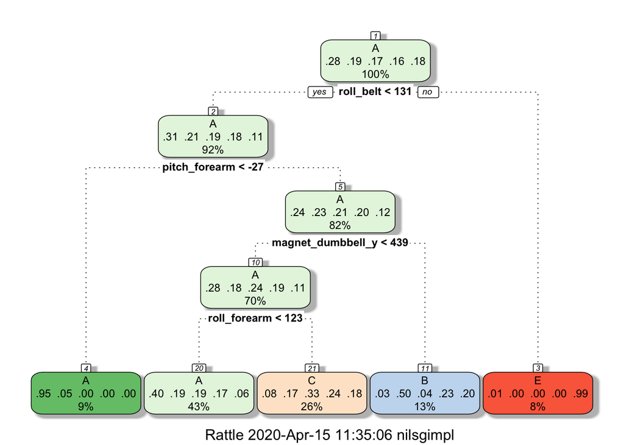

```r
fancyRpartPlot(model1$finalModel)
```